# HW05_ploter

```r
library(tidyverse)
library(tidymodels)
library(leaps)
library(rpart)
library(rpart.plot)
```

```r
set.seed(39692)
```

## Problem 1

1. Divide the data into training and model comparison parts (25% for model comparison).

```r
df = read_delim("hw5_C39692.csv", delim = ",")
splitted=initial_split(df,prop=0.75)
train_df=training(splitted)
test_df=testing(splitted)
head(test_df)
```

| X1 | X2 | X3 | X4 | X5 | X6 | X7 | X8 | X9 | X10 | X11 | X12 | X13 | X14 | country | X16 | X17 | X18 | X19 | y |
| --- | --- | --- | --- | --- | --- | --- | --- | --- | --- | --- | --- | --- | --- | --- | --- | --- | --- | --- | --- |
| 3.291877 | -1.7361823 | -2.2737945 | 6.538742 | 6.122394 | 3.195864 | 7.347778 | 1.554588 | 2.2211289 | 3.632268 | 8.959985 | 0.1469831 | 8.180958 | 0.3041080 | Estonia | 8.796883 | -0.3645963 | 1.692332 | -6.112842 | -9.778019 |
| 2.043911 | 0.5461518 | -3.3318382 | 6.833311 | 6.934972 | 1.179525 | -2.369914 | 8.028090 | 4.3020739 | 4.706501 | 1.668269 | -2.8261449 | 11.594899 | -0.2939983 | Estonia | 11.210156 | 4.8379786 | 2.576851 | -7.344961 | -1.625448 |
| 8.692776 | 2.4492922 | -0.4774947 | 7.101649 | 8.405079 | 6.767510 | 2.560468 | 3.708794 | 3.7281674 | 3.986644 | 1.521001 | -0.8963718 | 6.769694 | 7.2685331 | Estonia | 6.625115 | 10.8934703 | 5.030900 | -6.515374 | 6.566359 |
| 3.373102 | 0.1286761 | -4.1597909 | 8.913090 | 6.059373 | 3.741988 | -1.853477 | 9.184858 | 4.4740274 | 5.024033 | 4.353808 | -2.0360243 | 9.498568 | 1.7361393 | Estonia | 10.411198 | 11.0743238 | 4.322257 | -7.333231 | -3.713826 |
| 3.431347 | -1.0560341 | -4.7826645 | 5.076369 | 7.346264 | 1.879926 | 2.582307 | 8.228175 | 5.7413935 | 4.289729 | 1.428579 | -1.6210578 | 3.232395 | 4.4944275 | Estonia | 5.957124 | 2.0361860 | 2.912270 | -6.994047 | 13.976711 |
| 1.712496 | 3.3522584 | -0.2794923 | 5.600137 | 7.723406 | 1.654597 | -1.980422 | 1.070330 | 0.7713893 | 1.991143 | 2.601228 | -1.2991149 | 9.155052 | 0.6155646 | Latvia | 10.333563 | 5.9394812 | 2.429727 | -6.125865 | -16.806315 |

2. Use the training data to find the best Decision Tree model.

```r
rec1=recipe(y~.,data=train_df)
tree_spec=decision_tree(mode="regression",cost_complexity=tune(),min_n=5)|>set_engine("rpart",xval=0)
wf2=workflow()|>add_recipe(rec1)|>add_model(tree_spec)
cvdata=vfold_cv(train_df,v=5)
grid=data.frame(cost_complexity=10^seq(-6,0,length.out=11))
tune_result=wf2|>tune_grid(cvdata,grid=grid,metrics=metric_set(rmse))
show_best(tune_result)
```

| cost_complexity | .metric | .estimator | mean | n | std_err | .config |
| --- | --- | --- | --- | --- | --- | --- |
| 2.511886e-04 | rmse | standard | 5.538454 | 5 | 0.1355111 | Preprocessor1_Model05 |
| 3.981072e-06 | rmse | standard | 5.547313 | 5 | 0.1164506 | Preprocessor1_Model02 |
| 1.000000e-06 | rmse | standard | 5.549108 | 5 | 0.1167453 | Preprocessor1_Model01 |
| 1.584893e-05 | rmse | standard | 5.552477 | 5 | 0.1178797 | Preprocessor1_Model03 |
| 6.309573e-05 | rmse | standard | 5.567549 | 5 | 0.1207840 | Preprocessor1_Model04 |

```r
mod1=rpart::rpart(y~.,data=train_df, cp=select_best(tune_result, metric="rmse")$cost_complexity,minsplit=10,method="anova")

cp_8=as_tibble(mod1$cptable) |> filter(nsplit==8)|>pull(CP)
mod1$variable.importance
```

```
        X8         X5        X19         X1         X3         X7         X2         X6        X11         X9        X10
85721.4490 57817.8329 55810.8159 53771.9689 45963.9292 31929.0868 21583.9712 21094.8735 19274.1639 13174.7422  8828.9545
       X14        X17        X18        X13         X4        X16        X12    country
 5884.8183  5623.6233  5577.3957  5042.4522  4449.4950  2816.6147  1894.0486   559.3667
```

3. Produce a graph of the 8 most important splits of the best model

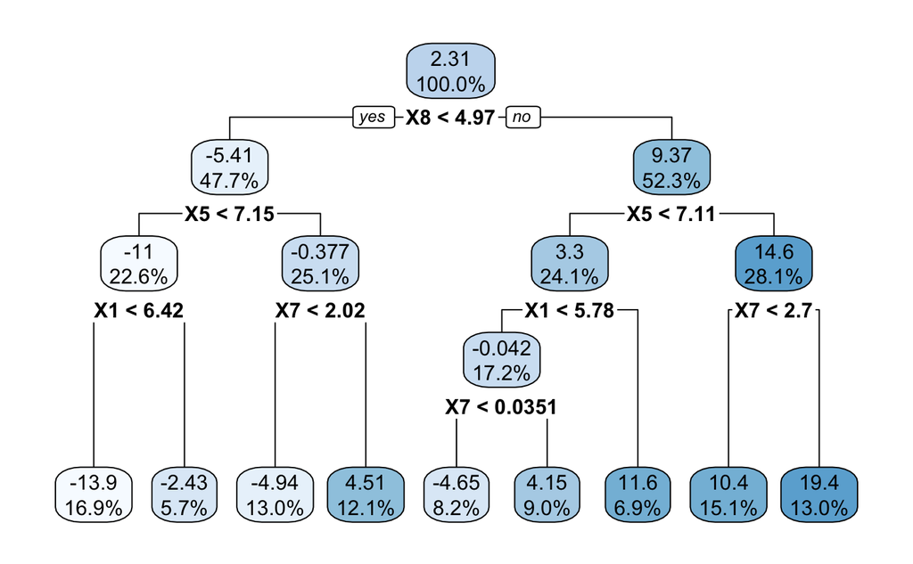

```r
rpart.plot::rpart.plot(rpart::prune(mod1,cp=cp_8),digits=3)
```

```r
print(rpart::prune(mod1, cp = cp_8))
```

```
n= 1500

node), split, n, deviance, yval
      * denotes terminal node

 1) root 1500 236910.400   2.31081900
   2) X8< 4.965312 716  72033.740  -5.41340300
     4) X5< 7.150743 339  24925.850 -11.01450000
       8) X1< 6.423427 254  12512.290 -13.88561000 *
       9) X1>=6.423427 85   4063.063  -2.43496800 *
     5) X5>=7.150743 377  26909.440  -0.37687050
      10) X7< 2.01632 195  10112.020  -4.94034200 *
      11) X7>=2.01632 182   8385.500   4.51256300 *
   3) X8>=4.965312 784  83143.630   9.36508400
     6) X5< 7.112997 362  28454.840   3.30375600
      12) X1< 5.783233 258  11212.130  -0.04204104
        24) X7< 0.03508377 123   3411.203  -4.64688800 *
        25) X7>=0.03508377 135   2816.425   4.15348700 *
      13) X1>=5.783233 104   7189.751  11.60391000 *
     7) X5>=7.112997 422  29980.210  14.56461000
      14) X7< 2.699056 227  12298.240  10.40900000 *
      15) X7>=2.699056 195   9198.507  19.40217000 *
```

4. Explain by the graph, which decisions are made to and which is the final prediction (based on the graph shown in the previous step) for observation corresponding to the row number 692 (the last three digits in your study book number) in the original data set.

```r
row_692 = df[692, ]
print(row_692)
```

| X1 | X2 | X3 | X4 | X5 | X6 | X7 | X8 | X9 | X10 | X11 | X12 | X13 | X14 | country | X16 | X17 | X18 | X19 | y |
| --- | --- | --- | --- | --- | --- | --- | --- | --- | --- | --- | --- | --- | --- | --- | --- | --- | --- | --- | --- |
| 8.726949 | -0.6846492 | -3.335671 | 6.357231 | 10.22865 | 18.65197 | 4.730494 | 1.069961 | 2.108965 | 2.689539 | 5.892538 | -1.738277 | 6.960006 | 9.701061 | Estonia | 7.647436 | 5.605534 | 3.762906 | -4.622532 | 16.15472 |

To explain the decisions made by the decision tree model for row 692, we’ll trace through the tree based on the values in row_692:

Node 1 (root) starting from the root node:

The root node checks if X8 < 4.97. For row 692, X8 = 1.069961, which is less than 4.97, so we go to the left subtree (Node 2).

Node 2: This node checks if X5 < 7.15. For row 692, X5 = 10.22865, which is greater than 7.15, so we proceed to the right subtree of this node (Node 5).

Node 5: This node checks if X7 < 2.02. For row 692, X7 = 4.730494, which is greater than 2.02, so we go to the right subtree of this node (Node 11).

Node 11 (Terminal Node): We reached the leaf, so the predicted value is 4.51.

```r
predicted_value = predict(rpart::prune(mod1,cp=cp_8), row_692)

actual_value = row_692$y

cat("Predicted value:", predicted_value, "\n")
```

```
Predicted value: 4.512563
```

5. Compute the performance (rmse) of the best model on the comparison part.

```r
test_df|>mutate(.pred=predict(mod1,test_df))|>rmse(truth=y,estimate=.pred)
```

| .metric | .estimator | .estimate |
| --- | --- | --- |
| rmse | standard | 5.11721 |

## Problem 2

1. Use the training data to find the best kNN model for predicting y by considering models with different number of predictors. Take into account the variable importance information from the best tree model to select predictors for the models you try, tune also with respect to the number of neighbors and with respect to the power of the distance metric.

```r
# Recipe 1: Top 3 predictors
rec_knn_1 = recipe(y ~ X8 + X5 + X19, data = train_df)

# Recipe 2: Top 5 predictors
rec_knn_2 = recipe(y ~ X8 + X5 + X19 + X1 + X3, data = train_df)

# Recipe 3: Top 7 predictors
rec_knn_3 = recipe(y ~ X8 + X5 + X19 + X1 + X3 + X7 + X2, data = train_df)

# Recipe 4: Top 9 predictors
rec_knn_4 = recipe(y ~ X8 + X5 + X19 + X1 + X3 + X7 + X2 + X6 + X11, data = train_df)

recipes_list = list(rec_knn_1, rec_knn_2, rec_knn_3, rec_knn_4)

tuning_grid=expand_grid(neighbors=c(5,10,20,40),dist_power=c(0.5,1,2))

knn_spec = nearest_neighbor(
  mode = "regression",
  neighbors = tune(),
  dist_power = tune()
) |>
  set_engine("kknn")

results = lapply(recipes_list, function(rec) {
  wf = workflow() |>
    add_recipe(rec) |>
    add_model(knn_spec)

  wf |>
    tune_grid(
      resamples = cvdata,
      grid = tuning_grid,
      metrics = metric_set(rmse)
    )
})

best_results = lapply(results, show_best, metric="rmse")
best_results
```

| neighbors | dist_power | .metric | .estimator | mean | n | std_err | .config |
| --- | --- | --- | --- | --- | --- | --- | --- |
| 40 | 1.0 | rmse | standard | 8.493649 | 5 | 0.06383262 | Preprocessor1_Model08 |
| 40 | 2.0 | rmse | standard | 8.497978 | 5 | 0.05466730 | Preprocessor1_Model12 |
| 40 | 0.5 | rmse | standard | 8.506799 | 5 | 0.08835532 | Preprocessor1_Model04 |
| 20 | 1.0 | rmse | standard | 8.572713 | 5 | 0.04243990 | Preprocessor1_Model07 |
| 20 | 0.5 | rmse | standard | 8.589591 | 5 | 0.06208750 | Preprocessor1_Model03 |

| neighbors | dist_power | .metric | .estimator | mean | n | std_err | .config |
| --- | --- | --- | --- | --- | --- | --- | --- |
| 20 | 2 | rmse | standard | 6.344009 | 5 | 0.1797844 | Preprocessor1_Model11 |
| 20 | 1 | rmse | standard | 6.390694 | 5 | 0.1854044 | Preprocessor1_Model07 |
| 40 | 2 | rmse | standard | 6.435408 | 5 | 0.1628214 | Preprocessor1_Model12 |
| 10 | 2 | rmse | standard | 6.440349 | 5 | 0.1799569 | Preprocessor1_Model10 |
| 10 | 1 | rmse | standard | 6.470778 | 5 | 0.1857192 | Preprocessor1_Model06 |

| neighbors | dist_power | .metric | .estimator | mean | n | std_err | .config |
| --- | --- | --- | --- | --- | --- | --- | --- |
| 10 | 2 | rmse | standard | 4.169213 | 5 | 0.08013006 | Preprocessor1_Model10 |
| 10 | 1 | rmse | standard | 4.268460 | 5 | 0.05993938 | Preprocessor1_Model06 |
| 20 | 2 | rmse | standard | 4.301203 | 5 | 0.08706829 | Preprocessor1_Model11 |
| 5 | 2 | rmse | standard | 4.305437 | 5 | 0.07234838 | Preprocessor1_Model09 |
| 20 | 1 | rmse | standard | 4.397501 | 5 | 0.05207451 | Preprocessor1_Model07 |

| neighbors | dist_power | .metric | .estimator | mean | n | std_err | .config |
| --- | --- | --- | --- | --- | --- | --- | --- |
| 10 | 2 | rmse | standard | 4.681244 | 5 | 0.08566981 | Preprocessor1_Model10 |
| 20 | 2 | rmse | standard | 4.769404 | 5 | 0.09801884 | Preprocessor1_Model11 |
| 10 | 1 | rmse | standard | 4.842128 | 5 | 0.04538031 | Preprocessor1_Model06 |
| 20 | 1 | rmse | standard | 4.875744 | 5 | 0.05528229 | Preprocessor1_Model07 |
| 5 | 2 | rmse | standard | 4.908710 | 5 | 0.07865935 | Preprocessor1_Model09 |

```
NA
```

2. Compute the performance of your best model for the comparison data. Which model (from the Decision Tree model and kNN model) would you choose for predicting new data and why?

```r
wf_knn = workflow() |>
  add_recipe(rec_knn_3) |>
  add_model(knn_spec)

cv_results_knn =   wf_knn |>
    tune_grid(
      resamples = cvdata,
      grid = tuning_grid,
      metrics = metric_set(rmse)
    )

best_knn = cv_results_knn |>
  select_best(metric="rmse")

final_knn = finalize_workflow(wf_knn, best_knn)

fitted_knn = fit(final_knn, data = train_df)

test_df = test_df |>
  mutate(.pred = predict(fitted_knn, test_df) |> pull(.pred))

knn_rmse = rmse(test_df, truth = y, estimate = .pred)
knn_rmse
```

| .metric | .estimator | .estimate |
| --- | --- | --- |
| rmse | standard | 4.1044 |

The kNN model has a lower RMSE (4.1044) than the Decision Tree model (5.11721). If predictive accuracy is the primary requirement, then we should choose the kNN model.

However, if results interpretability is also a requirement, we should not rule out the Decision Tree model.